# ExtraaLearn Project

## Context

The EdTech industry has been surging in the past decade immensely, and according to a forecast, the Online Education market would be worth $286.62bn by 2023 with a compound annual growth rate (CAGR) of 10.26% from 2018 to 2023. The modern era of online education has enforced a lot in its growth and expansion beyond any limit. Due to having many dominant features like ease of information sharing, personalized learning experience, transparency of assessment, etc, it is now preferable to traditional education.

In the present scenario due to the Covid-19, the online education sector has witnessed rapid growth and is attracting a lot of new customers. Due to this rapid growth, many new companies have emerged in this industry. With the availability and ease of use of digital marketing resources, companies can reach out to a wider audience with their offerings. The customers who show interest in these offerings are termed as leads. There are various sources of obtaining leads for Edtech companies, like

- The customer interacts with the marketing front on social media or other online platforms.
- The customer browses the website/app and downloads the brochure
- The customer connects through emails for more information.

The company then nurtures these leads and tries to convert them to paid customers. For this, the representative from the organization connects with the lead on call or through email to share further details.

## Objective

ExtraaLearn is an initial stage startup that offers programs on cutting-edge technologies to students and professionals to help them upskill/reskill. With a large number of leads being generated on a regular basis, one of the issues faced by ExtraaLearn is to identify which of the leads are more likely to convert so that they can allocate resources accordingly. You, as a data scientist at ExtraaLearn, have been provided the leads data to:

- Analyze and build an ML model to help identify which leads are more likely to convert to paid customers,
- Find the factors driving the lead conversion process
- Create a profile of the leads which are likely to convert

## Data Description

The data contains the different attributes of leads and their interaction details with ExtraaLearn. The detailed data dictionary is given below.

**Data Dictionary**

- ID: ID of the lead
- age: Age of the lead
- current_occupation: Current occupation of the lead. Values include 'Professional','Unemployed',and 'Student'
- first_interaction: How did the lead first interacted with ExtraaLearn. Values include 'Website', 'Mobile App'
- profile_completed: What percentage of profile has been filled by the lead on the website/mobile app. Values include Low - (0-50%), Medium - (50-75%), High (75-100%)
- website_visits: How many times has a lead visited the website
- time_spent_on_website: Total time spent on the website
- page_views_per_visit: Average number of pages on the website viewed during the visits.
- last_activity: Last interaction between the lead and ExtraaLearn.
  - Email Activity: Seeking for details about program through email, Representative shared information with lead like brochure of program , etc
  - Phone Activity: Had a Phone Conversation with representative, Had conversation over SMS with representative, etc
  - Website Activity: Interacted on live chat with representative, Updated profile on website, etc
- print_media_type1: Flag indicating whether the lead had seen the ad of ExtraaLearn in the Newspaper.
- print_media_type2: Flag indicating whether the lead had seen the ad of ExtraaLearn in the Magazine.
- digital_media: Flag indicating whether the lead had seen the ad of ExtraaLearn on the digital platforms.
- educational_channels: Flag indicating whether the lead had heard about ExtraaLearn in the education channels like online forums, discussion threads, educational websites, etc.
- referral: Flag indicating whether the lead had heard about ExtraaLearn through reference.
- status: Flag indicating whether the lead was converted to a paid customer or not.

## Mounting google drive

```python
%%capture
from google.colab import drive
drive.mount('/content/drive')
```

## Importing necessary libraries and data

```python
# Libraries for data manipulation

import pandas as pd
import numpy as np

# Library to split data
from sklearn.model_selection import train_test_split

# Libaries for data visualization
import matplotlib.pyplot as plt
import seaborn as sns
sns.set()

# Removes the limit for the number of displayed columns
pd.set_option("display.max_columns", None)
# Sets the limit for the number of displayed rows
pd.set_option("display.max_rows", 200)
# Sets the precision of floating numbers to 5 decimal points
pd.set_option("display.float_format", lambda x: "%.5f" % x)

# For building classification models
import statsmodels.stats.api as sms
from statsmodels.stats.outliers_influence import variance_inflation_factor
import statsmodels.api as sm
from statsmodels.tools.tools import add_constant
from sklearn.linear_model import LogisticRegression
from sklearn.tree import DecisionTreeClassifier
from sklearn import tree
from sklearn.ensemble import RandomForestClassifier

# For tuning the classification models
from sklearn.model_selection import GridSearchCV

# To get diferent metric scores
import sklearn.metrics as metrics
from sklearn.metrics import (
    f1_score,
    accuracy_score,
    recall_score,
    precision_score,
    confusion_matrix,
    classification_report,
    roc_auc_score,
    precision_recall_curve,
    roc_curve,
    make_scorer,
)

# To surpress warnings
import warnings
warnings.filterwarnings("ignore")
```

```python
# Importing the dataset
df = pd.read_csv('/content/drive/MyDrive/MIT ML & DS/ExtraaLearn.csv')
```

```python
# Creating a copy of df to avoid changes being made on the original dataset (df)
data = df.copy()
```

## Data Overview

- Observations
- Sanity checks

### Viewing the first and last 5 rows

```python
# First 5 rows
data.head(5)
```

|  | ID | age | current_occupation | first_interaction | profile_completed | website_visits | time_spent_on_website | page_views_per_visit | last_activity | print_media_type1 | print_media_type2 | digital_media | educational_channels | referral | status |
| --- | --- | --- | --- | --- | --- | --- | --- | --- | --- | --- | --- | --- | --- | --- | --- |
| 0 | EXT001 | 57 | Unemployed | Website | High | 7 | 1639 | 1.86100 | Website Activity | Yes | No | Yes | No | No | 1 |
| 1 | EXT002 | 56 | Professional | Mobile App | Medium | 2 | 83 | 0.32000 | Website Activity | No | No | No | Yes | No | 0 |
| 2 | EXT003 | 52 | Professional | Website | Medium | 3 | 330 | 0.07400 | Website Activity | No | No | Yes | No | No | 0 |
| 3 | EXT004 | 53 | Unemployed | Website | High | 4 | 464 | 2.05700 | Website Activity | No | No | No | No | No | 1 |
| 4 | EXT005 | 23 | Student | Website | High | 4 | 600 | 16.91400 | Email Activity | No | No | No | No | No | 0 |

```python
# Last 5 rows
data.tail(5)
```

|  | ID | age | current_occupation | first_interaction | profile_completed | website_visits | time_spent_on_website | page_views_per_visit | last_activity | print_media_type1 | print_media_type2 | digital_media | educational_channels | referral | status |
| --- | --- | --- | --- | --- | --- | --- | --- | --- | --- | --- | --- | --- | --- | --- | --- |
| 4607 | EXT4608 | 35 | Unemployed | Mobile App | Medium | 15 | 360 | 2.17000 | Phone Activity | No | No | No | Yes | No | 0 |
| 4608 | EXT4609 | 55 | Professional | Mobile App | Medium | 8 | 2327 | 5.39300 | Email Activity | No | No | No | No | No | 0 |
| 4609 | EXT4610 | 58 | Professional | Website | High | 2 | 212 | 2.69200 | Email Activity | No | No | No | No | No | 1 |
| 4610 | EXT4611 | 57 | Professional | Mobile App | Medium | 1 | 154 | 3.87900 | Website Activity | Yes | No | No | No | No | 0 |
| 4611 | EXT4612 | 55 | Professional | Website | Medium | 4 | 2290 | 2.07500 | Phone Activity | No | No | No | No | No | 0 |

### Understanding the shape of the dataset

```python
data.shape
```

```
(4612, 15)
```

- The dataset has 4612 rows and 15 columns.

### Checking the data types of the columns for the dataset

```python
data.info()
```

```
<class 'pandas.core.frame.DataFrame'>
RangeIndex: 4612 entries, 0 to 4611
Data columns (total 15 columns):
 #   Column                 Non-Null Count  Dtype
---  ------                 --------------  -----
 0   ID                     4612 non-null   object
 1   age                    4612 non-null   int64
 2   current_occupation     4612 non-null   object
 3   first_interaction      4612 non-null   object
 4   profile_completed      4612 non-null   object
 5   website_visits         4612 non-null   int64
 6   time_spent_on_website  4612 non-null   int64
 7   page_views_per_visit   4612 non-null   float64
 8   last_activity          4612 non-null   object
 9   print_media_type1      4612 non-null   object
 10  print_media_type2      4612 non-null   object
 11  digital_media          4612 non-null   object
 12  educational_channels   4612 non-null   object
 13  referral               4612 non-null   object
 14  status                 4612 non-null   int64
dtypes: float64(1), int64(4), object(10)
memory usage: 540.6+ KB
```

- There are no missing values in the dataset.

### Checking for duplicate rows in the dataset

```python
data.duplicated().sum()
```

```
0
```

- There are no duplicate rows in the dataset.

### Checking the number of unique values in each column

```python
data.nunique()
```

```
ID                       4612
age                        46
current_occupation          3
first_interaction           2
profile_completed           3
website_visits             27
time_spent_on_website    1623
page_views_per_visit     2414
last_activity               3
print_media_type1           2
print_media_type2           2
digital_media               2
educational_channels        2
referral                    2
status                      2
dtype: int64
```

- The 'ID' column has a unique value for each row. We can drop this column as there are no patterns that can be learned from this column. It will not add value to the model.
- Only the age, website_visits, time_spent_on_website, and page_views_per_visit columns are numerical. The rest of the columns are categorical.

```python
# Dropping the 'ID' column from the datast
data.drop(columns='ID',inplace=True)
```

### Checking the count of each unique category in each of the categorical variables

```python
# Creating a list of all catrgorical variables
cat_cols=['current_occupation', 'first_interaction', 'profile_completed', 'last_activity', 'print_media_type1', 'print_media_type2', 'digital_media', 'educational_channels', 'referral']

# Printing number of count of each unique value in each column
for i in cat_cols:
    print(data[i].value_counts())
    print('-'*50)
```

```
Professional    2616
Unemployed      1441
Student          555
Name: current_occupation, dtype: int64
--------------------------------------------------
Website       2542
Mobile App    2070
Name: first_interaction, dtype: int64
--------------------------------------------------
High      2264
Medium    2241
Low        107
Name: profile_completed, dtype: int64
--------------------------------------------------
Email Activity      2278
Phone Activity      1234
Website Activity    1100
Name: last_activity, dtype: int64
--------------------------------------------------
No     4115
Yes     497
Name: print_media_type1, dtype: int64
--------------------------------------------------
No     4379
Yes     233
Name: print_media_type2, dtype: int64
--------------------------------------------------
No     4085
Yes     527
Name: digital_media, dtype: int64
--------------------------------------------------
No     3907
Yes     705
Name: educational_channels, dtype: int64
--------------------------------------------------
No     4519
Yes      93
Name: referral, dtype: int64
--------------------------------------------------
```

- Most leads belong to the 'professional' and 'unemployed' categories. Surprisingly, the company only has few student leads.
- Most of the leads have filled their profile at least 50%, which suggests the leads find the process of filling their profile convenient. This could be because of the user-friendly design of the company's website and mobile app.
- Almost 50% of the last interaction between the company and leads have taken place via emails.
- In terms of the company's paid advertising channels, the advertising seems to have been successful in aquiring leads in the following order: advertisement on digital media, followed by print media type 1 and then print media type 2.
- Educational channels have played a bigger role in aquiring leads than any of the advertising channels the company used, and that too, most likely without any cost.

### Summary statistics of numerical variables

```python
data.describe().T
```

|  | count | mean | std | min | 25% | 50% | 75% | max |
| --- | --- | --- | --- | --- | --- | --- | --- | --- |
| age | 4612.00000 | 46.20121 | 13.16145 | 18.00000 | 36.00000 | 51.00000 | 57.00000 | 63.00000 |
| website_visits | 4612.00000 | 3.56678 | 2.82913 | 0.00000 | 2.00000 | 3.00000 | 5.00000 | 30.00000 |
| time_spent_on_website | 4612.00000 | 724.01127 | 743.82868 | 0.00000 | 148.75000 | 376.00000 | 1336.75000 | 2537.00000 |
| page_views_per_visit | 4612.00000 | 3.02613 | 1.96812 | 0.00000 | 2.07775 | 2.79200 | 3.75625 | 18.43400 |
| status | 4612.00000 | 0.29857 | 0.45768 | 0.00000 | 0.00000 | 0.00000 | 1.00000 | 1.00000 |

- Average age of the leads is 46. The range is 18 years to 63 years. Interestingly, more than 50% of the leads are aged over 51.
- On average, a lead has visited the website 3.5 times. Some leads haven't visited the website at all. There seems to outliers present as the 75th percentile value is 5 and the max value is 30.
- On average, a lead has spent 724 seconds (12 mins) on the website. Some leads haven't spent any time at all on the website. There's a big difference between the 50th and 75th percentile values (376 secs vs 1336 secs). And, outliers seem to be present as the 75th percentile value is 1336 secs and max value is 2537 secs.
- A lead has visited about 3 pages on the website on average. Again, some leads haven't visited the website at all. Outliers seem to be present as the 75th percentile value is 3.7 and max value is 18.4.

### Checking the percentage class distribution of the target variable

```python
data['status'].value_counts(normalize=True)*100
```

```
0   70.14310
1   29.85690
Name: status, dtype: float64
```

- As most values in the target varible are 0, there is imbalance in the distribution of this variable.

## Exploratory Data Analysis (EDA)

- EDA is an important part of any project involving data.
- It is important to investigate and understand the data better before building a model with it.
- A few questions have been mentioned below which will help you approach the analysis in the right manner and generate insights from the data.
- A thorough analysis of the data, in addition to the questions mentioned below, should be done.

**Questions**

1. Leads will have different expectations from the outcome of the course and the current occupation may play a key role in getting them to participate in the program. Find out how current occupation affects lead status.
2. The company's first impression on the customer must have an impact. Do the first channels of interaction have an impact on the lead status?
3. The company uses multiple modes to interact with prospects. Which way of interaction works best?
4. The company gets leads from various channels such as print media, digital media, referrals, etc. Which of these channels have the highest lead conversion rate?
5. People browsing the website or mobile application are generally required to create a profile by sharing their personal data before they can access additional information.Does having more details about a prospect increase the chances of conversion?

### Univariate analysis

#### Creating functions for analysis

```python
# Defining a function to plot both histogram and boxplots
def hist_and_box(data, column):
    f, (ax_box, ax_hist) = plt.subplots(2, sharex=True, gridspec_kw={'height_ratios': (0.15, 0.85)}, figsize=(12, 6))

    # Adding a graph in each axis
    sns.boxplot(data=data, x=column, ax=ax_box, showmeans=True)
    sns.histplot(data=data, x=column, kde=True, ax=ax_hist)

    # Add mean to the histogram
    ax_hist.axvline(data[column].mean(), color='g', linestyle='--')

    # Add median to the histogram
    ax_hist.axvline(data[column].median(), color='r', linestyle='-')

    plt.show()
```

```python
# Defining a function to plot bar plots
def bar_and_distribution(data, column):
  # Plotting bar plot
  plt.figure(figsize = (6, 5))
  sns.countplot(x = data[column], palette='Greens')
  plt.show()

  # Calculating percentage distribution
  print('\033[1m' + 'Percentage distribution' + '\033[0m')
  print(data[column].value_counts(normalize=True)*100)
```

#### Age

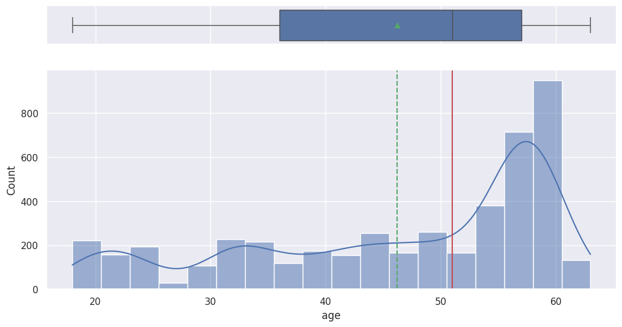

```python
hist_and_box(data, 'age')
```

- Distribution of age is left-skewed.
- 50th percentile value is 51 and max value is 63. This shows 50% of the leads are between the age group of 51 to about 63, which is unusual and interesting. Usually, the oppossite behavior is expected where the young people show more interest in online education than old people. Also, the age group that has the highest number of leads is close to 60 years.
- Box plot confirms there are no outliers.

#### Website visits

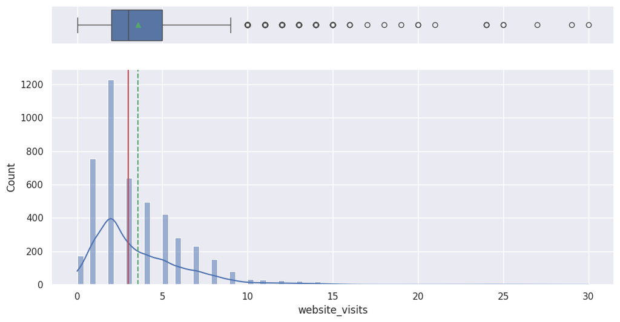

```python
hist_and_box(data, 'website_visits')
```

- Distribution is right-skewed.
- Mean and median values are close (3.5 and 3 respectively).
- Most leads have visited the website between 0-9 times.
- Box plot shows there are outliers present. Let's check how many such values are there.

```python
# Calculating the number of rows where website_visits value is above 9
(data['website_visits'] > 9).sum()
```

```
154
```

- There are 154 outliers. Dropping these rows will mean losing about 3% of the dataset, which is not a small number. Also, the max value of the column is 30 visits. While 30 visits is high, it is not an impossible observation. Given these reasons, I'm not going to drop these outliers.

#### Time spent on website

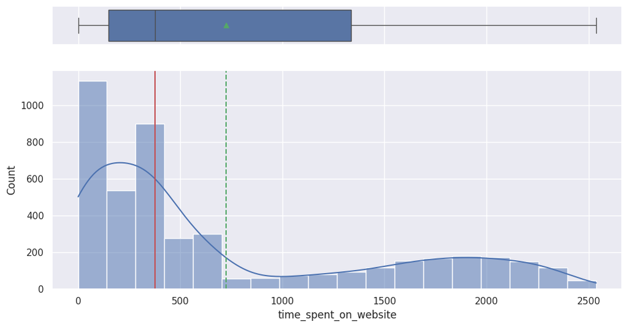

```python
hist_and_box(data, 'time_spent_on_website')
```

- Distribution is right-skewed.
- There is a higher concentration of observations between 0 seconds to about 700 seconds or 12 mins.
- Box plot shows there are no outliers present. While there is a big difference between the 75th percentile and max values, the max value of 2537 seconds or 42 mins is not an unlikely observation.

#### Page views per visit

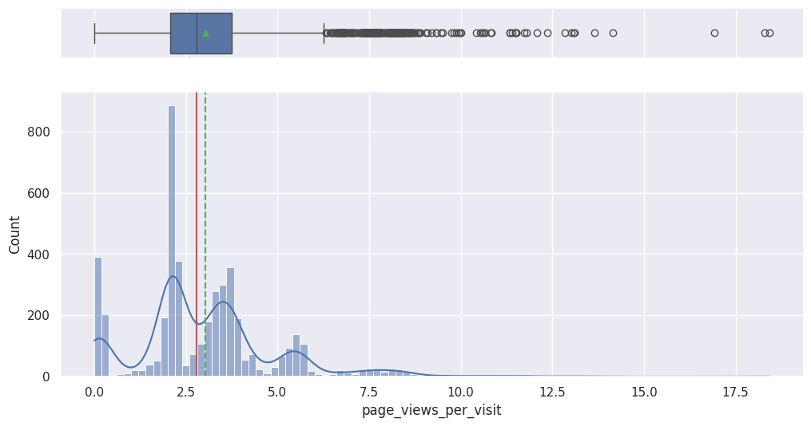

```python
hist_and_box(data, 'page_views_per_visit')
```

- Distribution is right-skewed, with most of the observations lying between 0 - about 3.75 pages per visit.
- Mean and median are very close to each other (3 and 2.8 respectively).
- Box plot shows there are outliers present. Let's check how many such values are there.

```python
# Calculating the number of rows where page_views_per_visit value is above 6.25
(data['page_views_per_visit'] > 6.25).sum()
```

```
260
```

- There are 260 outliers. Dropping these rows will mean losing about 5.6% of the dataset, which is not a small number. Hence, I'm not going to drop these outliers.

#### Current occupation

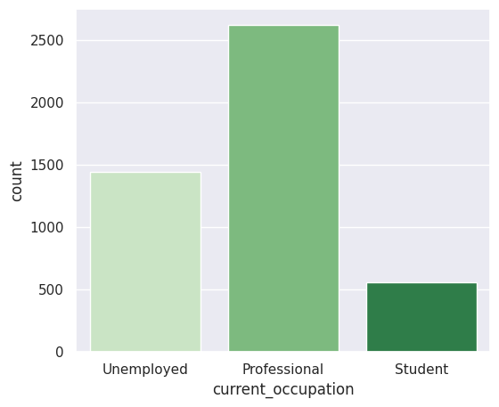

```
Percentage distribution
Professional   56.72160
Unemployed     31.24458
Student        12.03382
Name: current_occupation, dtype: float64
```

```python
bar_and_distribution(data, 'current_occupation')
```

- 57% of the leads are working professionals, which is significantly higher than the other two categories.
- As seen earlier, only 12% of the leads are students, which is counter-intuitive. There may be room for improvement here.

#### First interaction

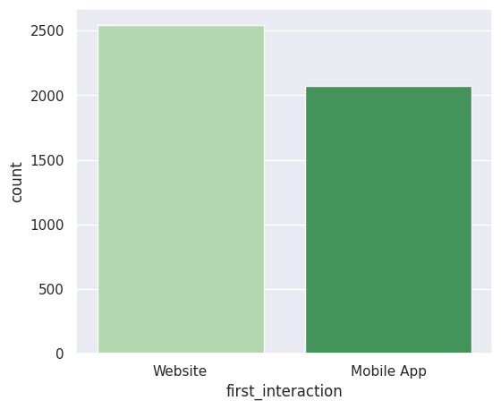

```
Percentage distribution
Website      55.11709
Mobile App   44.88291
Name: first_interaction, dtype: float64
```

```python
bar_and_distribution(data, 'first_interaction')
```

- First interaction of the leads with the company via website (55%) is higher than via mobile app (45%).But, these values are somewhat close. This suggests both the platforms seem to be almost equally preferred by the leads.

#### Profile completed

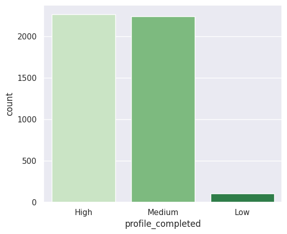

```
Percentage distribution
High     49.08933
Medium   48.59063
Low       2.32003
Name: profile_completed, dtype: float64
```

```python
bar_and_distribution(data, 'profile_completed')
```

- 49% of the leads have filled their profile more than 75%, and 48% have filled their profile more than 50%. This shows approx 97% of the leads have filled their profiles at least 50%. This suggests the company's website and mobile app have been largely successful in obtaining the personal infomation of the leads.

#### Last activity

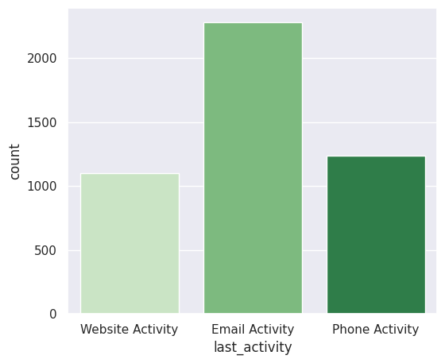

```
Percentage distribution
Email Activity     49.39289
Phone Activity     26.75629
Website Activity   23.85082
Name: last_activity, dtype: float64
```

```python
bar_and_distribution(data, 'last_activity')
```

- Almost 50% of the last interactions between the leads and the company have taken place through email. The remaining intractions have taken place through phone and website which both share a similar percentage (27% & 23% respectively).
- This suggests the company should put more focus on email activities to increase the conversion rate to a paid customer.

#### Print media type 1

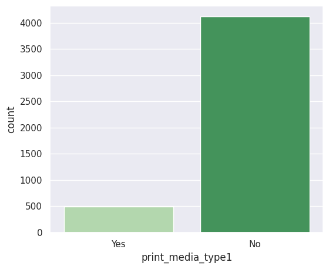

```
Percentage distribution
No    89.22376
Yes   10.77624
Name: print_media_type1, dtype: float64
```

```python
bar_and_distribution(data, 'print_media_type1')
```

- Only 10% of the leads had seen the ad in newspaper, which shows this advertising channel has not been successful in generating leads.

#### Print media type 2

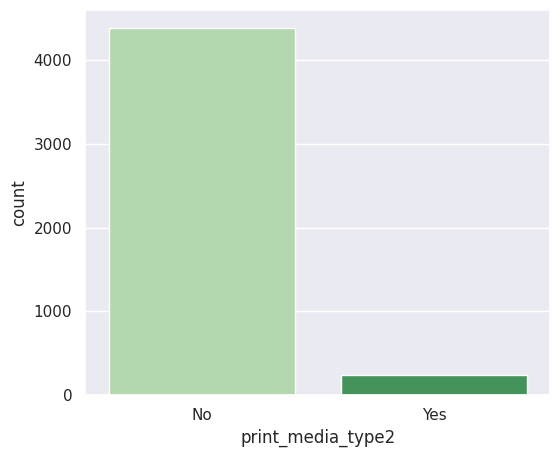

```
Percentage distribution
No    94.94796
Yes    5.05204
Name: print_media_type2, dtype: float64
```

```python
bar_and_distribution(data, 'print_media_type2')
```

- Only 5% of the leads had seen the ad in magazine, which shows this advertising channel too has not been successful in generating leads.

#### Digital media

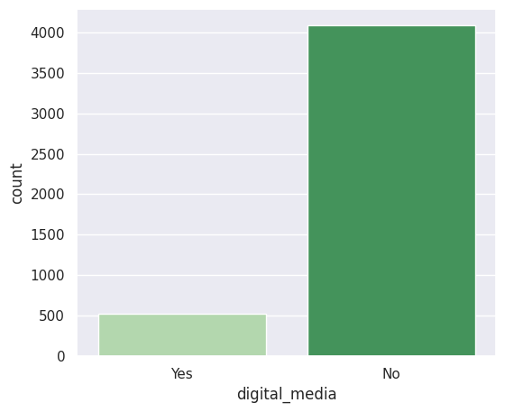

```
Percentage distribution
No    88.57329
Yes   11.42671
Name: digital_media, dtype: float64
```

```python
bar_and_distribution(data, 'digital_media')
```

- Only 11% of the leads had seen the ad on digital platforms, which shows this advertising channel too has not been successful in generating leads.

#### Educational channels

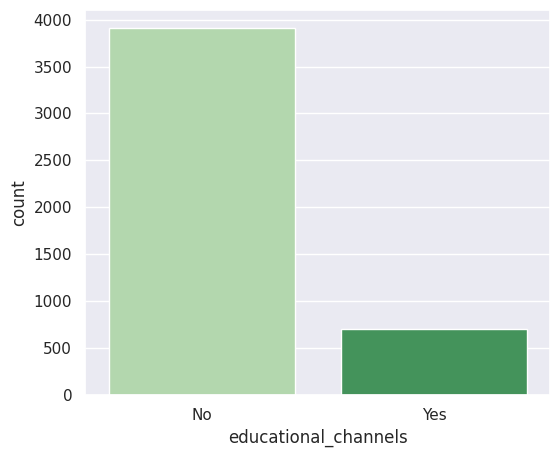

```
Percentage distribution
No    84.71379
Yes   15.28621
Name: educational_channels, dtype: float64
```

```python
bar_and_distribution(data, 'educational_channels')
```

- 15% of the leads generated had heard about ExtraaLearn through educational channels. And, these channels most likely would not have cost the company any money.
- Among all the five communication mediums through which the leads are generated, educational channels have given the best result, which suggests the company ought to give more importance to this medium.

#### Referral

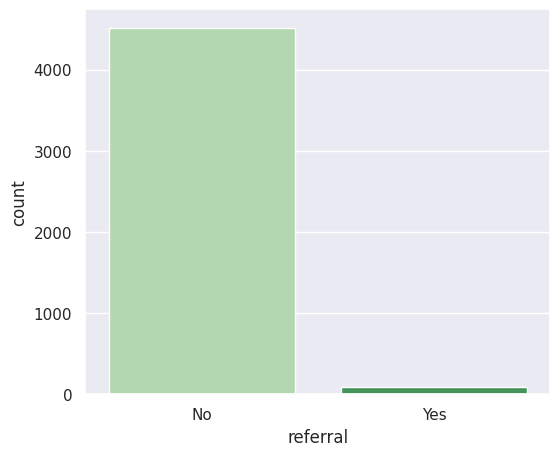

```
Percentage distribution
No    97.98352
Yes    2.01648
Name: referral, dtype: float64
```

```python
bar_and_distribution(data, 'referral')
```

- Only 2% of the leads generated had heard about ExtraaLearn through referrals, which shows this communication medium has not been successful in generating leads.

### Bivariate and multivariate analysis

#### Correlation matrix for numerical variables

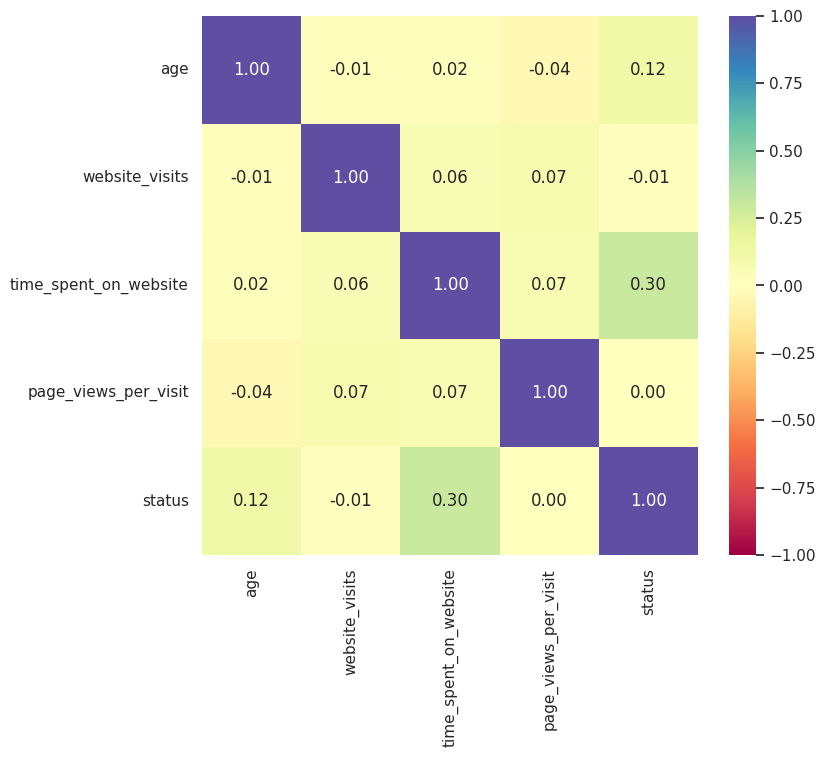

```python
num_cols = data.select_dtypes(include=np.number).columns.tolist()

plt.figure(figsize=(8, 7))
sns.heatmap(data[num_cols].corr(), annot=True, vmin=-1, vmax=1, fmt=".2f", cmap="Spectral")
plt.show()
```

- There is considerable positive correlation between time_spent_on_website and status. This is the highest correlation observed. This indicates the more the time spent by a lead on the website, higher the chances of him/her turning into a paid customer.
- There is also a decent positive correlation between age and status. This indicates the higher the age of a lead, higher the chances of him/her turning into a paid customer.
- Other than the above, there is no correlation to almost no correlation is observed between the other variables.

#### Creating functions for further analysis

```python
# Defining a function to plot ditributions against each target class
def distribution_plot_wrt_target(data, predictor, target):

    fig, axs = plt.subplots(2, 2, figsize=(12, 10))

    target_uniq = data[target].unique()

    axs[0, 0].set_title("Distribution of target for target=" + str(target_uniq[0]))
    sns.histplot(
        data=data[data[target] == target_uniq[0]],
        x=predictor,
        kde=True,
        ax=axs[0, 0],
        color="teal",
        stat="density",
    )

    axs[0, 1].set_title("Distribution of target for target=" + str(target_uniq[1]))
    sns.histplot(
        data=data[data[target] == target_uniq[1]],
        x=predictor,
        kde=True,
        ax=axs[0, 1],
        color="orange",
        stat="density",
    )

    axs[1, 0].set_title("Boxplot w.r.t target")
    sns.boxplot(data=data, x=target, y=predictor, ax=axs[1, 0], palette="gist_rainbow")

    axs[1, 1].set_title("Boxplot (without outliers) w.r.t target")
    sns.boxplot(
        data=data,
        x=target,
        y=predictor,
        ax=axs[1, 1],
        showfliers=False,
        palette="gist_rainbow",
    )

    plt.tight_layout()
    plt.show()
```

```python
# Defining the stacked barplot function
def stacked_barplot(data,predictor,target,figsize=(8,6)):
  (pd.crosstab(data[predictor],data[target],normalize='index')*100).plot(kind='bar',figsize=figsize,stacked=True)
  plt.legend(loc="lower right")
  plt.ylabel(target)
```

#### Relationship between current occupation vs status

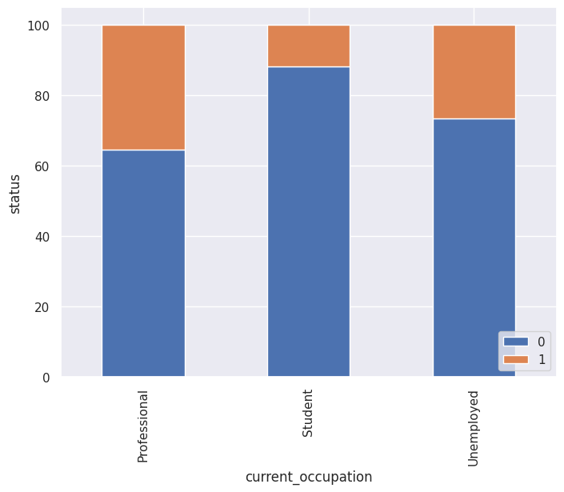

```python
# Stacked bar plot for current occupation vs status
stacked_barplot(data, 'current_occupation', 'status')
```

- As seen earlier, most of the leads are professionals, followed by 'unemployed' and 'student' categories. Similarly, the conversion rate of these categories also follow the same order. This shows the company is generating leads appropriately across the 3 categories.
- Let's analyse further by looking at age vs current_occupation.

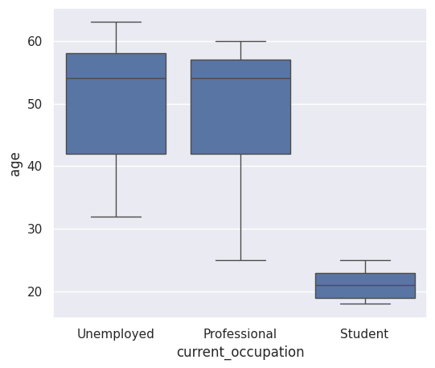

```python
# Bar plot to look at the distribution of age against each category of current occupation
plt.figure(figsize=(6, 5))
sns.boxplot(data = data, x = data['current_occupation'], y = data['age'])
plt.show()
```

```python
# Grouping current occupation by age and generating summary statistics
data.groupby('current_occupation')['age'].describe()
```

| current_occupation | count | mean | std | min | 25% | 50% | 75% | max |
| --- | --- | --- | --- | --- | --- | --- | --- | --- |
| Professional | 2616.00000 | 49.34748 | 9.89074 | 25.00000 | 42.00000 | 54.00000 | 57.00000 | 60.00000 |
| Student | 555.00000 | 21.14414 | 2.00111 | 18.00000 | 19.00000 | 21.00000 | 23.00000 | 25.00000 |
| Unemployed | 1441.00000 | 50.14018 | 9.99950 | 32.00000 | 42.00000 | 54.00000 | 58.00000 | 63.00000 |

- 'Student' category's age distribution, 18 years - 25 years, is very limited. Typically, people from this age group who are mostly students and individuals starting to work cannot afford additional money for online education. This explains why this category has the least conversion rate.
- 'Professional' category's age distribution is 25 years - 60 years. This age group would mostly consist of individuals who are working professionals with some experience, and hence they would be able to afford additional money on online education. This explains the highest conversion rate.
- Though the 'Unemployed' category largely covers similar age group as that of 'professional' category, it doesn't include the 25 years - 31 years age group which could be the reason for its conversion rate being lower than that of 'professional' category.
- In summary, professionals demonstrate the highest conversion rate, followed by 'unemployed' and then 'student' categories.

#### Relationship between first interaction and status

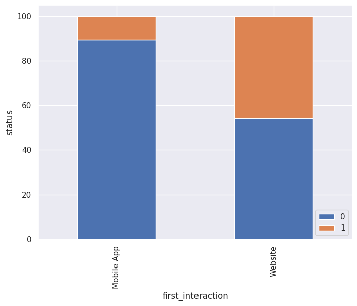

```python
# Stacked bar plot for first interaction vs status
stacked_barplot(data, 'first_interaction', 'status')
```

- Though the proportion of leads interacted with mobile app and the proportion of leads that interacted with website are somewhat close, website performs significantly better in converting leads to paid customers.
- The medium with which a lead first interacts plays a significant role in the chances of converting the lead to a paid customer. By increasing the number of leads whose first interaction is with the website, there is a clear opportunity for increasing the number of paid customers.
- The company can further enhance their website (with more relevant information, being more user firendly, etc.), which could potentially help to further increase the conversion rate.
- Also, the company should look into the reasons behind the clear lapse in performance of mobile app and address them.
- Next, let's analyse other predictor variables that are related to website against the target variable.

#### Relationship between time spent on website and status

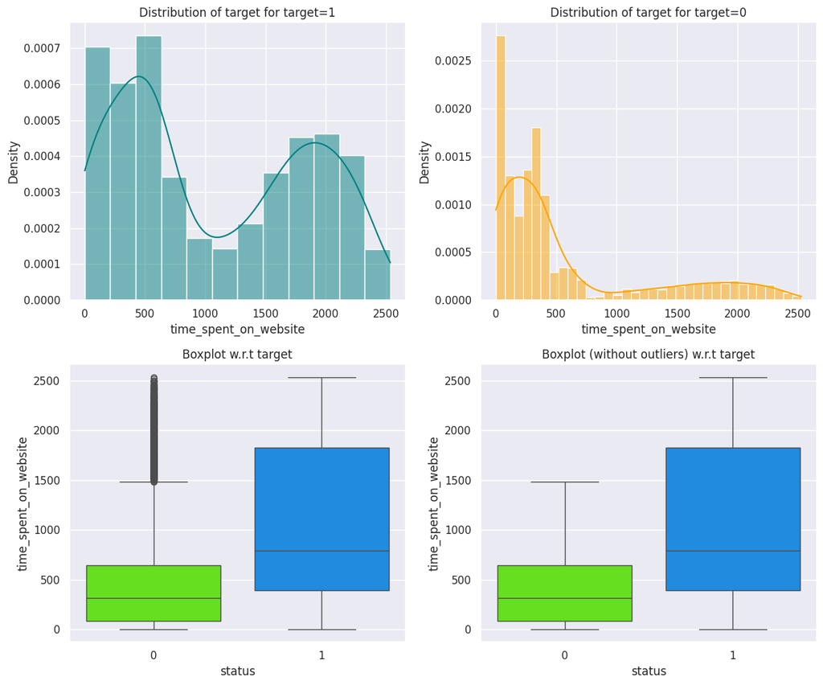

```python
# Plotting ditributions of time spent on website against each target class
distribution_plot_wrt_target(data, 'time_spent_on_website', 'status')
```

```python
# Calculating the median value for each target class
data.groupby('status')['time_spent_on_website'].median()
```

```
status
0   317.00000
1   789.00000
Name: time_spent_on_website, dtype: float64
```

#### Relationship between page views per visit and status

- As seen in the correlation matrix, there is no correlation at all between the variables. Hence, further analysis will not be meaningful.

#### Relationship between website visits and status

- As seen in the correlation matrix, there is almost no correlation between the variables. Hence, further analysis will not be meaningful.

#### Relationship between age and status

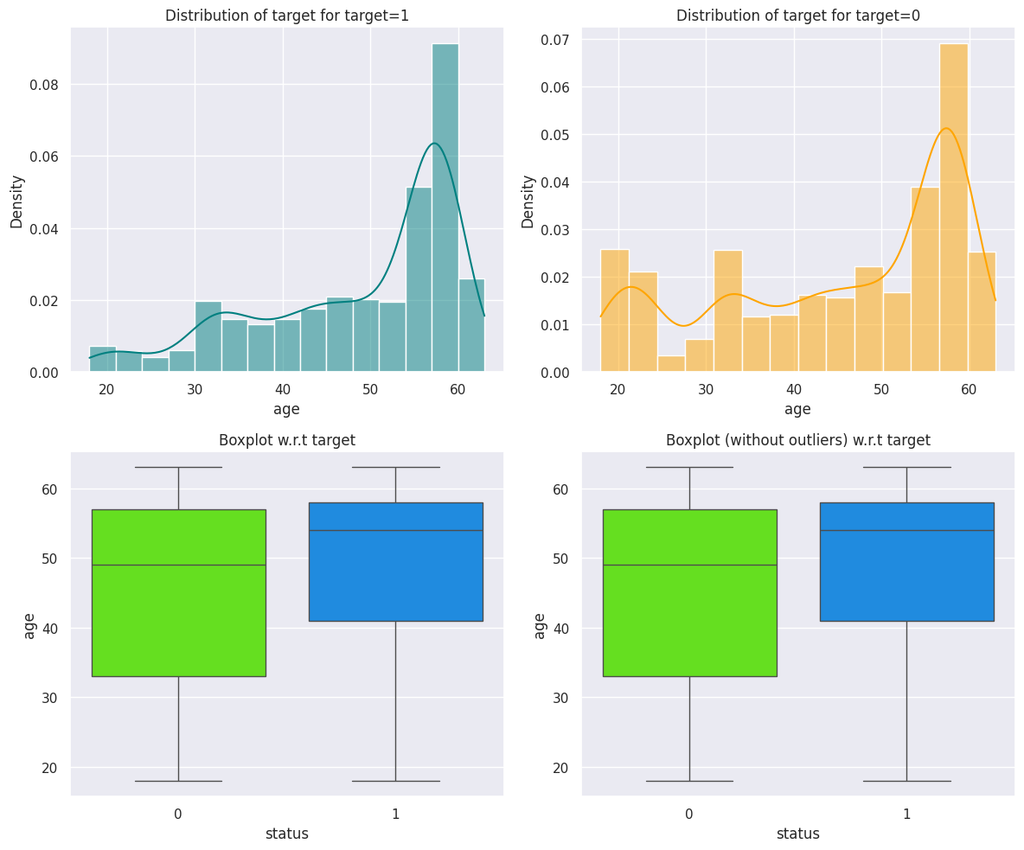

```python
# Plotting ditributions of age against each target class
distribution_plot_wrt_target(data, 'age', 'status')
```

```python
# Calculating the median value for each target class
data.groupby('status')['age'].median()
```

```
status
0   49.00000
1   54.00000
Name: age, dtype: float64
```

#### Relationship between profile completed and status

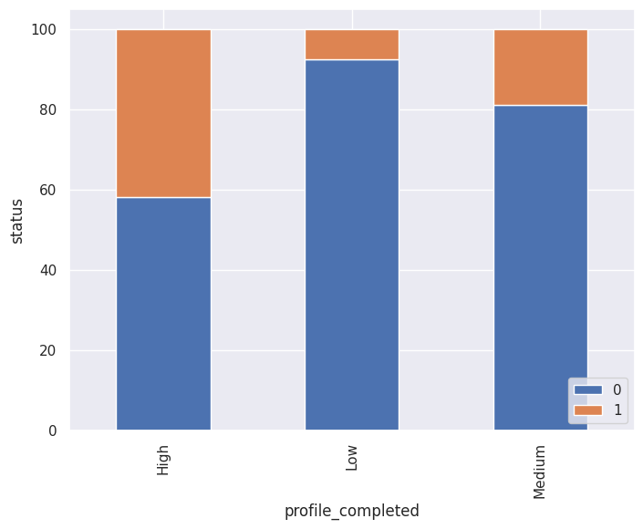

```python
# Stacked bar plot for profile completed vs status
stacked_barplot(data, 'profile_completed', 'status')
```

- As seen above, there is a clear relationship between the extent to which leads fill their profiles and converting into paid customers.
- The more a profile is filled the higher the chances of conversion. With more personal information available about a lead, the company's likely able to understand the potential customer better (their needs, their financial situation, etc.) and thereby provide them with appropriate offers.
- The company can benefit from finding ways to further increase profile completions.

#### Relationship between last activity and status

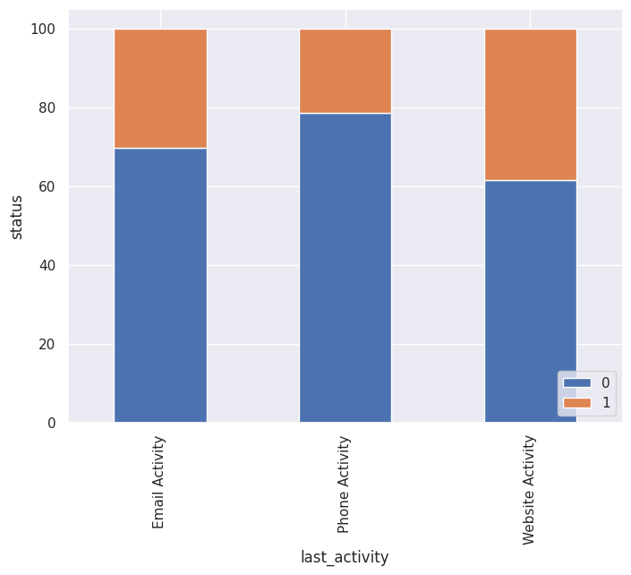

```python
# Stacked bar plot for last activity vs status
stacked_barplot(data, 'last_activity', 'status')
```

- The conversion rate is the highest when the last interaction between the company and a lead is on the website.
- Interestingly, as seen earlier, the last interaction with almost 50% of the prospects were on emails, while only about 24% of the prospects' last interaction was on websites. This makes a clear recommendation that the company should prioritize the three communication mediums according to their their conversion rates when communicating with the leads.

#### Relationship between print media type 1 and status

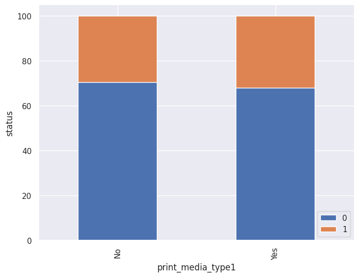

```python
# Stacked bar plot for print media type 1 vs status
stacked_barplot(data, 'print_media_type1', 'status')
```

- The conversion rate is similar for both categories. Hence, this variable alone cannot provide useful insights in predicting conversion.

#### Relationship between print media type 2 and status

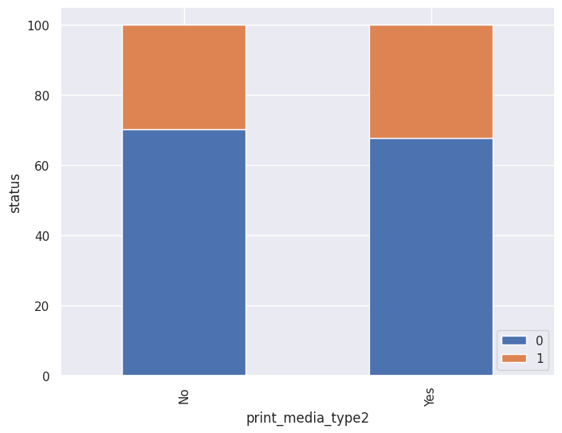

```python
# Stacked bar plot for print media type 2 vs status
stacked_barplot(data, 'print_media_type2', 'status')
```

- The conversion rate is similar for both categories. Hence, this variable alone cannot provide useful insights in predicting conversion.

#### Relationship between digital media and status

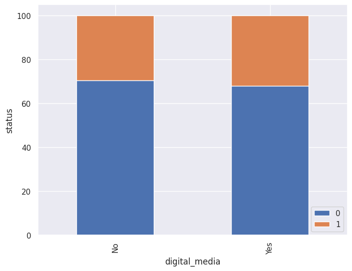

```python
# Stacked bar plot for digital media vs status
stacked_barplot(data, 'digital_media', 'status')
```

- The conversion rate is similar for both categories. Hence, this variable alone cannot provide useful insights in predicting conversion.

#### Relationship between educational channels and status

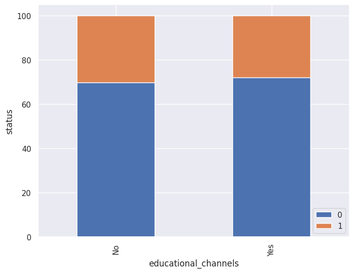

```python
# Stacked bar plot for educational channels vs status
stacked_barplot(data, 'educational_channels', 'status')
```

- The conversion rate is similar for both categories. Hence, this variable alone cannot provide useful insights in predicting conversion.

#### Relationship between referral and status

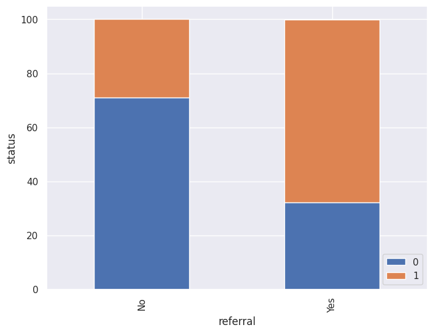

```python
# Stacked bar plot for referral vs status
stacked_barplot(data, 'referral', 'status')
```

- The conversion rate of leads generated from referral is significantly higher (about two folds) than that of non-referral category. Typically, referrals come from people who have dealt with the company already and hence referrals are considered to be reliable. This is the likely reason for the trend observed in the graph.
- Out of all the 5 channels through which the company gets leads, referral has the highest conversion rate.
- As seen earlier, only 2% of the leads had heard about the company through referal before becoming leads. So, the company can focus on increasing the number of referrals, and that is likely to increase their paid customer base.

## Data Preprocessing

- Missing value treatment (if needed)
- Feature engineering (if needed)
- Outlier detection and treatment (if needed)
- Preparing data for modeling
- Any other preprocessing steps (if needed)

```python
# Separating target variable and other variables
X = data.drop(columns = 'status')
Y = data['status']
```

```python
# Encoding categorical varaibles
X = pd.get_dummies(X, columns= cat_cols, drop_first=True)
```

```python
# Splitting the data into train and test sets
X_train,X_test,y_train,y_test = train_test_split(X,Y,test_size=0.30,random_state=1,stratify=Y)
```

```python
# Inspecting the train and test sets
print("Shape of Training set : ", X_train.shape)
print("Shape of test set : ", X_test.shape)
print("*" * 40)
print("Percentage of classes in training set:")
print(y_train.value_counts(normalize=True))
print("*" * 40)
print("Percentage of classes in test set:")
print(y_test.value_counts(normalize=True))
```

```
Shape of Training set :  (3228, 16)
Shape of test set :  (1384, 16)
Percentage of classes in training set:
0   0.70136
1   0.29864
Name: status, dtype: float64
Percentage of classes in test set:
0   0.70159
1   0.29841
Name: status, dtype: float64
```

## Building models

### Model evaluation criterion

- Predicting a lead would not get converted where the lead would have converted would result in potential customer. This is the biggest loss for the company, and hence it will be the model evaluation criterion.
- This will mean the model should maximize 'Recall'. Higher the recall score lower the false negatives will be.

### Creating functions to calculate different metrics for model's performance

```python
# Function to print classification report and plot confusion matrix
def metrics_score(actual, predicted):
    print(classification_report(actual, predicted))

    cm = confusion_matrix(actual, predicted)
    plt.figure(figsize=(8,5))

    sns.heatmap(cm, annot=True,  fmt='.2f', xticklabels = ['Not Converted', 'Converted'], yticklabels = ['Not Converted', 'Converted'])
    plt.ylabel('Actual')
    plt.xlabel('Predicted')
    plt.show()
```

### Building a Decision Tree model

```python
# Fitting and training the model
model_dt = DecisionTreeClassifier(random_state=1)
model_dt.fit(X_train, y_train)
```

```
DecisionTreeClassifier(random_state=1)
```

```
              precision    recall  f1-score   support

           0       1.00      1.00      1.00      2264
           1       1.00      1.00      1.00       964

    accuracy                           1.00      3228
   macro avg       1.00      1.00      1.00      3228
weighted avg       1.00      1.00      1.00      3228
```

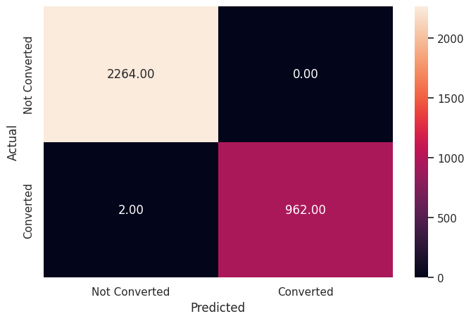

```python
# Checking model performance on the training dataset
pred_train_dt = model_dt.predict(X_train)
metrics_score(y_train, pred_train_dt)
```

- Almost all the leads have been classified correcty. Almost zero errors in classification. Model has perfomed very well on the training set.
- As we didn't apply any restriction to the model, the decision tree will continue to grow until all the patterns in the dataset are learnt and each data point is correctly classified. This is the reason for this perfect performance.
- Let's check the performance on test dataset to see if the model is overfitting.

```
              precision    recall  f1-score   support

           0       0.86      0.87      0.86       971
           1       0.68      0.67      0.68       413

    accuracy                           0.81      1384
   macro avg       0.77      0.77      0.77      1384
weighted avg       0.81      0.81      0.81      1384
```

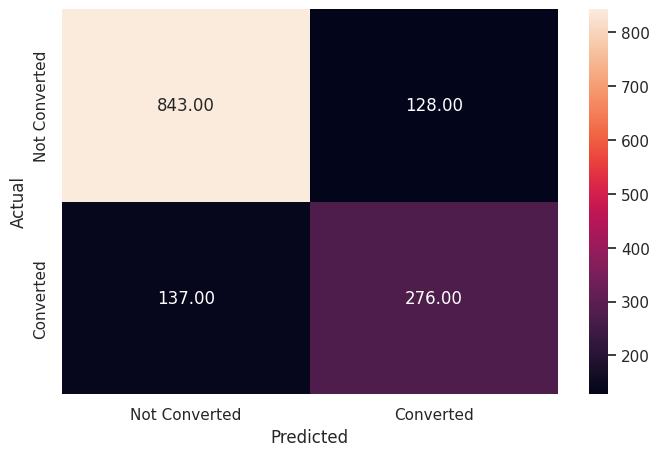

```python
# Checking model performance on the test dataset
pred_test_dt = model_dt.predict(X_test)
metrics_score(y_test, pred_test_dt)
```

- The model is clearly overfitting the training dataset as the model's performance across all the metrics has significantly reduced on the test dataset.
- Let's tune the model to see if we can reduce the overfitting.

#### Hyperparameter tuning for the decision tree model using GridSearch CV

- We will use the class_weight hyperparameter with the value equal to {0: 0.3, 1: 0.7} which is approximately the opposite of the imbalance in the original data. This is done to handle the imbalance in the original data.

```python
# Choosing the classifier
estimator_tuned = DecisionTreeClassifier(class_weight = {0: 0.3, 1: 0.7}, random_state=1)

# Grid of parameters to choose from
parameters = {
    "max_depth": np.arange(1,10),
    "max_leaf_nodes": [50, 75, 150, 250],
    "min_samples_split": [10, 30, 50, 70],
    'criterion': ['gini', 'entropy']
}

# Type of scoring used to compare the parameter combinations - recall score for class 1
scorer = metrics.make_scorer(recall_score, pos_label = 1)

# Running the grid search
grid_obj = GridSearchCV(estimator_tuned, parameters, cv=5, scoring=scorer, n_jobs=-1)
grid_obj = grid_obj.fit(X_train, y_train)

# Set the classifier to the best combination of parameters
estimator_tuned = grid_obj.best_estimator_

# Fit the best algorithm to the data
estimator_tuned.fit(X_train, y_train)
```

```
DecisionTreeClassifier(class_weight={0: 0.3, 1: 0.7}, criterion='entropy',
                       max_depth=3, max_leaf_nodes=50, min_samples_split=10,
                       random_state=1)
```

```
              precision    recall  f1-score   support

           0       0.95      0.75      0.84      2264
           1       0.60      0.91      0.72       964

    accuracy                           0.79      3228
   macro avg       0.78      0.83      0.78      3228
weighted avg       0.85      0.79      0.80      3228
```

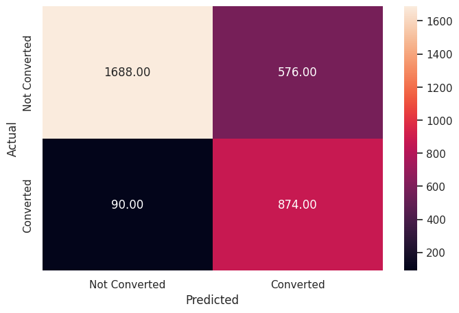

```python
# Checking model performance on the training dataset
tuned_train_dt = estimator_tuned.predict(X_train)
metrics_score(y_train, tuned_train_dt)
```

```
              precision    recall  f1-score   support

           0       0.94      0.73      0.82       971
           1       0.58      0.89      0.70       413

    accuracy                           0.78      1384
   macro avg       0.76      0.81      0.76      1384
weighted avg       0.83      0.78      0.79      1384
```

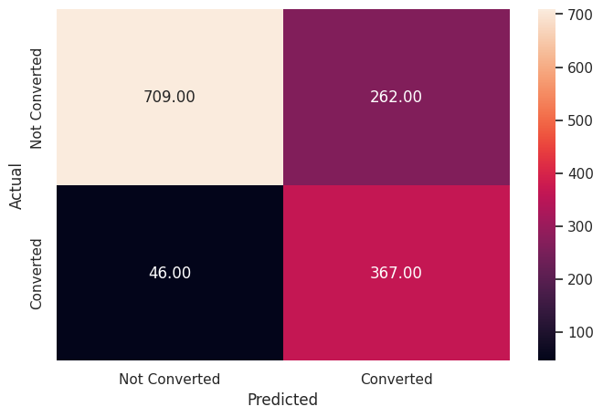

```python
# Checking model performance on the test dataset
tuned_test_dt = estimator_tuned.predict(X_test)
metrics_score(y_test, tuned_test_dt)
```

#### Visulaizing the fine-tuned decision tree model

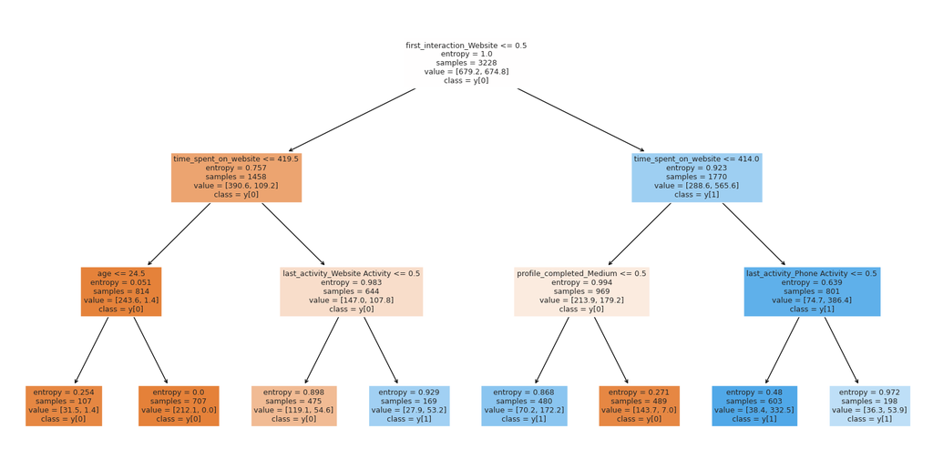

```python
# Plotting the decision tree
feature_names = list(X_train.columns)
plt.figure(figsize=(20, 10))
out = tree.plot_tree(
    estimator_tuned,
    max_depth=4,
    feature_names=feature_names,
    filled=True,
    fontsize=9,
    node_ids=False,
    class_names=True,
)

# To add arrows to the decision tree split if they are missing
for o in out:
    arrow = o.arrow_patch
    if arrow is not None:
        arrow.set_edgecolor("black")
        arrow.set_linewidth(1)
plt.show()
```

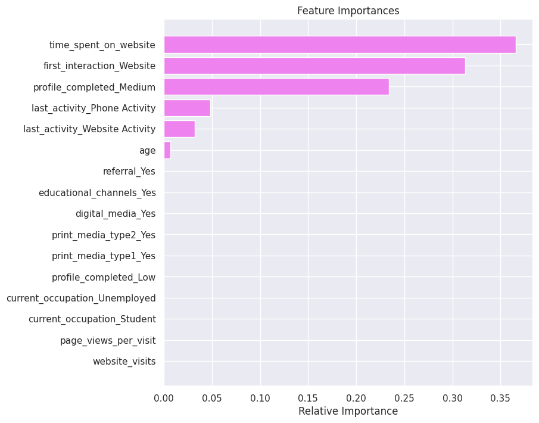

```python
# Importance of features in the tree building
importances = estimator_tuned.feature_importances_
indices = np.argsort(importances)

plt.figure(figsize=(8, 8))
plt.title("Feature Importances")
plt.barh(range(len(indices)), importances[indices], color="violet", align="center")
plt.yticks(range(len(indices)), [feature_names[i] for i in indices])
plt.xlabel("Relative Importance")
plt.show()
```

- The most important variables in classifying whether a lead will be converted are: time_spent_on_website, first_interaction_website and profile_completed_medium. They are followed by Last activity and age variables.
- Rest of the variables have no importance in the said classification.

#### Do we need to prune the tree?

- Pruning is applied to address overfitting. The fine-tuned decision tree model is not overfitting anymore as we have seen and is performing well as shown by the performance metrics. So, pruning is not necessary here.

### Building a Random Forest model

```python
# Fitting and training the model
rf_estimator = RandomForestClassifier(random_state = 1)
rf_estimator.fit(X_train, y_train)
```

```
RandomForestClassifier(random_state=1)
```

```
              precision    recall  f1-score   support

           0       1.00      1.00      1.00      2264
           1       1.00      1.00      1.00       964

    accuracy                           1.00      3228
   macro avg       1.00      1.00      1.00      3228
weighted avg       1.00      1.00      1.00      3228
```

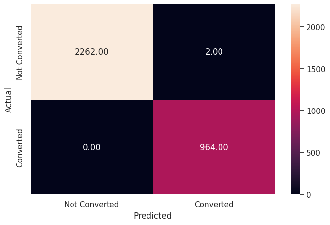

```python
# Checking the model performance on training dataset
y_pred_train_rf = rf_estimator.predict(X_train)

metrics_score(y_train, y_pred_train_rf)
```

- Almost zero classification errors on the training dataset. Model has performed very well on the training set. This perfect performance is due to the same reason I explained under the decision tree model.
- Let's check the performance on test dataset to see if the model is overfitting.

```
              precision    recall  f1-score   support

           0       0.89      0.91      0.90       971
           1       0.78      0.73      0.76       413

    accuracy                           0.86      1384
   macro avg       0.83      0.82      0.83      1384
weighted avg       0.86      0.86      0.86      1384
```

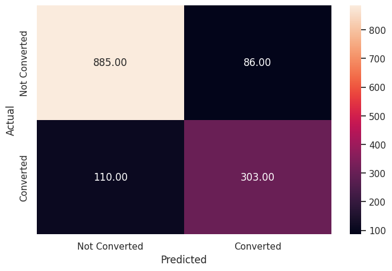

```python
# Checking the model performance on test dataset
y_pred_test_rf = rf_estimator.predict(X_test)

metrics_score(y_test, y_pred_test_rf)
```

- The model is clearly overfitting the training dataset as the model's performance across all the metrics has significantly reduced on the test dataset.
- Let's tune the model to see if we can reduce the overfitting.

#### Hyperparameter tuning for the Random Forest model using GridSearch CV

```python
# Choose the classifier
rf_estimator_tuned = RandomForestClassifier(class_weight = {0: 0.3, 1: 0.7}, random_state = 1)

# Grid of parameters to choose from
params_rf = {"n_estimators": [110, 120],
    "max_depth": [6, 7],
    "min_samples_leaf": [20, 25],
    "max_features": [0.8, 0.9],
    "max_samples": [0.9, 1]
             }

# Type of scoring used to compare parameter combinations - recall score for class 1
scorer = metrics.make_scorer(recall_score, pos_label = 1)

# Run the grid search
grid_obj = GridSearchCV(rf_estimator_tuned, params_rf, scoring = scorer, cv = 5)

grid_obj = grid_obj.fit(X_train, y_train)

# Set the classifier to the best combination of parameters
rf_estimator_tuned = grid_obj.best_estimator_

# Fit the best algorithm to the data
rf_estimator_tuned.fit(X_train, y_train)
```

```
RandomForestClassifier(class_weight={0: 0.3, 1: 0.7}, max_depth=6,
                       max_features=0.8, max_samples=0.9, min_samples_leaf=25,
                       n_estimators=110, random_state=1)
```

```
              precision    recall  f1-score   support

           0       0.94      0.82      0.88      2264
           1       0.67      0.89      0.77       964

    accuracy                           0.84      3228
   macro avg       0.81      0.85      0.82      3228
weighted avg       0.86      0.84      0.84      3228
```

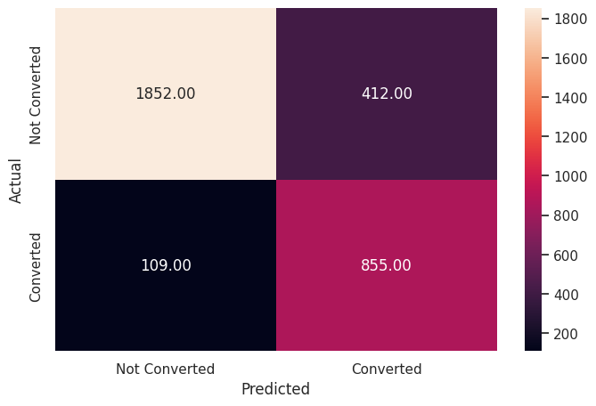

```python
# Checking the model performance on the training dataset
y_pred_train_rf_tuned = rf_estimator_tuned.predict(X_train)

metrics_score(y_train, y_pred_train_rf_tuned)
```

```
              precision    recall  f1-score   support

           0       0.93      0.81      0.86       971
           1       0.65      0.85      0.74       413

    accuracy                           0.82      1384
   macro avg       0.79      0.83      0.80      1384
weighted avg       0.84      0.82      0.82      1384
```

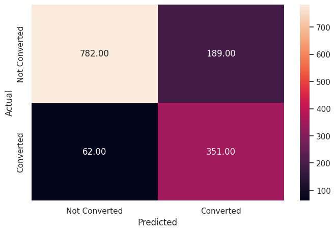

```python
# Checking the model performance on the test dataset
y_pred_test_rf_tuned = rf_estimator_tuned.predict(X_test)

metrics_score(y_test, y_pred_test_rf_tuned)
```

- Random forest model with default parameters is overfitting the training data. However, it was still able to generalize somewhat well on the test dataset.
- The tuned model was able to fix this overfitting and generalize well on unseen data. This is evident by the similar values observed for precision, recall, F1 score, and accuracy across both the training and test datasets. Recall, our main metric of interest, has increased from 73% to 85% (from default model to fine tuned model) on the unseen data (test dataset).
- In the fine-tuned model, the only metric that is towards the lower side is precision. But, as precision is not our main metric of interest, it is not a major concern.
- Hence, the fine-tuned model is a good model that the company can use for prediction.

#### Visualizing the fine-tuned Random Forest model

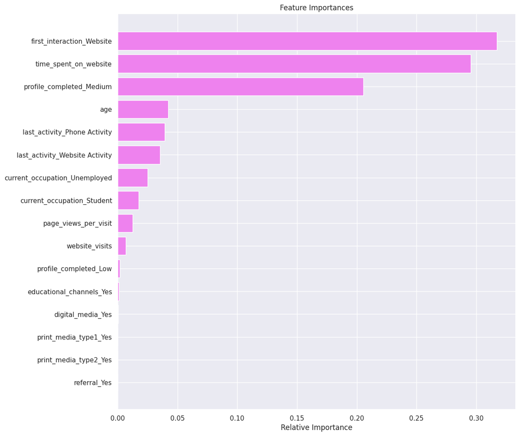

```python
# Plotting feature importance
importances = rf_estimator_tuned.feature_importances_

indices = np.argsort(importances)

feature_names = list(X.columns)

plt.figure(figsize = (12, 12))

plt.title('Feature Importances')

plt.barh(range(len(indices)), importances[indices], color = 'violet', align = 'center')

plt.yticks(range(len(indices)), [feature_names[i] for i in indices])

plt.xlabel('Relative Importance')

plt.show()
```

- The most important variables in classifying whether a lead will be converted are: first_interaction_website, time_spent_on_website, and profile_completed_medium. They are followed by age and Last activity variables.
- Unlike the fine-tuned decision tree model, this model gives importance to some other variables (current occupation, page_views_per_visit, etc.) as well. These variables have very little to no importance in the said classification.
- The above-noted observations are similar to that of the fine-tuned decision tree model, which indicates these two models perform similarly.

#### Do we need to prune the tree?

- Pruning is applied to address overfitting. The fine-tuned random forest model is not overfitting anymore as we have seen and is performing well as shown by the performance metrics. So, pruning is not necessary here.

### Which is the best model?

- There are two best performing models. Both the fine-tuned decision tree model and fine-tuned random forest model exhibit similar performance on unseen data (test dataset). And, in both these models, the recall values are close. Hence, the company can rely on either of these two models for their prediction.

## Actionable Insights and Recommendations

1. In terms of occupation, most of the leads are professionals, followed by 'unemployed' and 'student' categories. Similarly, the conversion rate of these categories also follow the same order. This shows the company is generating leads appropriately across the 3 categories, which also means their resources are being allocated appropriately. They should cotinue this.
2. Among the occupations, interestingly, 'Student' category has the least number of leads and the least conversion rate. This is likely owing to their age distribution (18-25 years) which makes it difficult for them to afford the online education being offered by ExtraaLearn.The company should focus on designing suitable programs at affordable prices for young students as there is an immense potential for growth in conversion here. The right programs and prices have the ability to attract masses of young students as paid customers.
3. As much as possible. the company should try to ensure the first interaction of the leads is with the company website. By doing so, the conversion rate approximately increases by 3 folds compared to the mobile app being the first platform the leads interact with.

In line with this, a finding shows the more time the leads spend on the website the higher the chances of conversion. In summary, the website performs a clear role in conversion, and hence sufficent importance should be given to it by the company.

4. Last insight also highlights a clear lapse in the performance of the mobile app compared to that of the website, which the company should address.
5. The more a profile is filled the higher the chances of conversion. With more information available about a lead, the company can better serve the lead. Therefore, the company can benefit from further increasing profile completions as approximately 50% of the profiles are only filled halfway.
6. Conversion rate is the highest when the last interaction between the company and a lead is on the website compared to the other mediums of last interaction. However, only about 24% of the prospects' last interaction was on websites. The company can benefit by prioritizig the three communication mediums (email, phone and website) according to their conversion rates when interacting with the leads.
7. Out of all the 5 channels through which the company gets leads, referral has the highest conversion rate. But, only 2% of the leads had heard about the company through referal before becoming leads. The company focusing on increasing the number of referrals is likely to increase their paid customer base.
8. Profile of a lead that is likely to convert: